# Project 2 - Visualization

Bingqi Lian

INST680

Dr. Gibson

11/02/2024

## Introduction:

The dataset for this project, entitled 'Student Mental Health 2021', is derived from the Borealis Dataverse repository and can be accessed here: *https://borealisdata.ca/dataset.xhtml?persistentId=doi%3A10.5683%2FSP3%2FVEIBVL*. The dataset is collected by the University of Victoria in Canada from 2020 fall to 2021 to capture aspects of student mental health in higher education, focusing on factors such as stress, anxiety and depression (as measured by the DASS and PSS scales), as well as lifestyle variables such as exercise habits, sleep quality and social support. This dataset is focusing on the population of participants who are self-identified as current college/university students in Canada. The dataset include 147 variables and 1192 observations (qualified participants).

**Formal Citation:** Paterson, Theone; Reeves, Jennifer, 2022, "University Student Mental Health [Student_Mental_Health_2021-10-10]", https://doi.org/10.5683/SP3/VEIBVL, Borealis, V2, UNF:6:2tyVJl3esN2hxWezxJ7/Fg== [fileUNF]

**Project Background:** The goal of this project is to analyze and visualize the data for the mental health status among college students to better understand how various factors contribute to stress, anxiety, and depression among students aged 18-25, which is a common age range of college/university students. According to the original project proposal, the analysis aims to:

1. Determine the relationship between demographic characteristics such as age, gender, race, and school year and Depression Anxiety Stress Scale(DASS) and Perceived Stress Scale (PSS) scores.
2. Examine how lifestyle variables (including frequency of exercise, sleep patterns, and living arrangements) affect students' mental health.
3. Assess the impact of social support and mindfulness practice on stress and emotional well-being.
4. Provide detailed visualizations of effects and insights for stakeholders to understand the most critical factors affecting student mental health.

The primary motivation behind this project was to create a resource that college different mental health relevant resources for **educational institutions, mental health professionals, public health policymakers, and college/university students** to get mental health support, or develop tailored interventions, support systems, and wellness programs for students.

This project involved various visualization tasks designed to:

1. Explore the relationship of age, gender, race, and school year to mental health outcomes.
2. Assess the impact of living arrangements and exercise habits on DASS and PSS scores.
3. Investigate the relationship between sleep quality (duration of sleep and feeling rested) and mental health scores.
4. Analyze how social support (SSS) and mindfulness practice (CAMS) affect perceived stress and emotional well-being.

These visualizations and analyses provide insights into potential risk factors and protective measures that can be leveraged to improve mental health resources for students. By understanding the interplay between these factors, institutions can better support their student populations, leading to healthier and more productive academic environments.

## Method of Analysis:

The analysis for this project was carefully designed to ensure a thorough understanding of the dataset and to uncover meaningful insights that aligned with the project goals. The first step was extensive data cleaning and preparation to address any inconsistencies or missing entries in the dataset. This included transforming categorical variables such as gender, ethnicity, and living arrangement into corresponding labels based on the mappings provided in the dataset documentation. These conversions are critical for accurate analysis and clear visual presentation. In addition, new columns were created to represent the total scores for DASS (Depression, Anxiety, Stress Scale), PSS (Perceived Stress Scale), SSS (Seeking Social Support), and CAMS-R (Mindfulness). These total scores were calculated by summing the corresponding items of each scale to arrive at a composite measure of each variable for further analysis.

Once the dataset was ready, it was filtered to focus on students aged 18-25 years old to fit within the expected range of the project's analysis of mental health trends among students in that age group. The datasets were then grouped according to specific variables such as age, academic grade, and living arrangement to facilitate the calculation of median and mean DASS and PSS scores for the different subgroups. These aggregations provide a detailed understanding of how mental health indicators vary across demographic and lifestyle factors.

Visualization played a pivotal role in presenting the findings and making the data accessible. A diverse range of visualizations was employed to bring clarity to the analysis. For age-based analysis, line graphs depicting mean and median of DASS and PSS scores to identify mental health trends across various ages within the 18-25 demographic. Gender and ethnicity comparisons were presented using box plots and bar charts to illustrate the distribution of scores, and highlight any significant disparities or variations in stress, anxiety, and depression levels among different groups. This step was essential to reveal potential vulnerabilities among specific populations.

The influence of lifestyle factors was also explored, particularly in exercise frequency and sleep patterns. Line graphs were used to present DASS and PSS scores to the frequency of strenuous, moderate, and mild exercise. This visualization aimed to determine if the specific types or levels of physical activity correlates with improved mental health outcomes. For sleep patterns, combined line graphs were created to examine the relationship between the number of hours slept, the feeling of being well-rested, and mental health scores. This dual approach sheds light on the importance of both sleep duration and sleep quality in managing stress and emotional well-being.

Finally, the impact of social support and mindfulness practices was analyzed using total scores from the SSS and CAMS scales. Line graphs were constructed to depict how median DASS and PSS scores varied with increasing levels of social support and mindfulness. This analysis revealed the significance of external and internal coping mechanisms in mitigating stress and enhancing mental health resilience.

To create these visualizations, Python libraries such as Matplotlib and Seaborn were utilized due to their versatility and capability to produce high-quality graphics. Data manipulation tasks, including grouping and calculating medians and means, were performed using Pandas, which facilitated efficient data handling and ensured accuracy in the analysis.

The primary goal of these visualizations was to present complex mental health data in an intuitive format, making it easier to interpret and draw actionable conclusions. The combination of statistical analysis and visual exploration captured both general trends and specific anomalies, providing a holistic view of how various factors influence student mental health. This approach not only enhanced the understanding of potential risk factors but also highlighted protective measures that could be adopted by educational institutions and health professionals to support students more efficiently.

## Findings and Interpretation

The analysis of the dataset on student mental health status among those aged 18-25 revealed several critical insights through various visualizations that align with the project proposal. Below are the key findings, structured to highlight the importance and implications of each factor studied:

(For more detailed information, please see the code and the visualization parts below)

```python
import pandas as pd
import matplotlib.pyplot as plt
import seaborn as sns

# Load the dataset
df = pd.read_csv('02_Student_Mental_Health_2021-10-10.csv')

# df.shape
df.head()
```

|  | StartDate | EndDate | Duration (in seconds) | Eligibility | Age | Ethnicity | Ethnicity_text | Sex | Gender | Year_credits | ... | Post_PSS_1 | Post_PSS_2 | Post_PSS_3 | Post_PSS_4 | Post_PSS_5 | Post_PSS_6 | Post_PSS_7 | Post_PSS_8 | Post_PSS_9 | Post_PSS_10 |
| --- | --- | --- | --- | --- | --- | --- | --- | --- | --- | --- | --- | --- | --- | --- | --- | --- | --- | --- | --- | --- | --- |
| 0 | 9/22/2020 13:57 | 9/22/2020 14:05 | 461 | 1 | 18 | 2 | NaN | 2 | 2 | 1 | ... | 4 | 3 | 3 | 1 | 3 | 3 | 2 | 3 | 3 | 3 |
| 1 | 9/22/2020 14:16 | 9/22/2020 14:36 | 1215 | 1 | 18 | 1 | NaN | 2 | 2 | 1 | ... | 5 | 4 | 3 | 4 | 2 | 2 | 3 | 4 | 3 | 2 |
| 2 | 9/22/2020 14:59 | 9/22/2020 15:07 | 526 | 1 | 18 | 2 | NaN | 2 | 2 | 1 | ... | 2 | 3 | 4 | 3 | 4 | 4 | 2 | 3 | 4 | 4 |
| 3 | 9/22/2020 16:07 | 9/22/2020 16:15 | 516 | 1 | 19 | 1 | NaN | 2 | 2 | 1 | ... | 4 | 4 | 5 | 4 | 2 | 4 | 3 | 3 | 4 | 3 |
| 4 | 9/22/2020 17:15 | 9/22/2020 18:01 | 2751 | 1 | 18 | 1 | NaN | 2 | 2 | 1 | ... | 2 | 1 | 5 | 4 | 3 | 3 | 4 | 3 | 5 | 3 |

5 rows × 147 columns

## Data Preparation

Let's convert the categorical data from numberical value to categorical value

```python
# Change the values of categorical attributes based on the information from the README file

## Creating dictionaries for categorical value replacements
# Ethnicity mapping
ethnicity_map = {
    1: 'Caucasian', 2: 'Asian', 3: 'Indigenous', 4: 'Hispanic/Latino',
    5: 'Black', 6: 'Other', 7: 'Metis'}

# Sex mapping
sex_map = {
    1: 'Male', 2: 'Female', 3: 'Intersex'}

# Gender mapping
gender_map = {
    1: 'Male', 2: 'Female', 3: 'Non-binary/Genderqueer', 12: 'Other/Not listed'}

# Year credits mapping
year_credits_map = {
    1: 'Year 1/Freshman', 2: 'Year 2/Sophomore', 3: 'Year 3/Junior',
    4: 'Year 4/Senior', 5: 'Year 5/Super Senior'}

# Year calendar mapping
year_calendar_map = {
    1: 'Year 1', 2: 'Year 2', 3: 'Year 3', 4: 'Year 4',
    5: 'Year 5', 6: 'Year 6', 7: 'Year 7', 8: 'Year 8+'}

# Program mapping
program_map = {
    1: 'Business', 2: 'Education', 3: 'Engineering', 4: 'Fine Arts',
    5: 'Human and Social Development', 6: 'Humanities', 7: 'Sciences', 8: 'Social Sciences'}

# Part-time/full-time mapping
part_time_map = {
    1: 'Part-time', 2: 'Full-time'}

# Degree mapping
degree_map = {
    1: 'First degree', 2: 'Completed one previous degree',
    3: 'Completed three or more previous degrees', 4: 'Completed two previous degrees'}

# Living situation mapping
living_map = {
    1: 'Residences/On-campus', 2: 'Off-campus with family',
    3: 'Off-campus with friends/roommates', 4: 'Off-campus alone'}

# International student mapping
international_map = {
    1: 'Yes', 2: 'No'}

# Strenuous Exercise mapping
Strenuous_exercise_map = {
    20: 0, 21: 1, 22: 2, 23: 3, 24: 4, 25: 5, 26: 6, 36: 7, 37: 8, 38: 9, 39: 10, 40: 11,
    41: 12, 42: 13, 43: 14, 44: 15, 45: 16, 46: 17, 47: 18, 48: 19, 49: 20, 50: 21, 51: 22,
    52: 23, 53: 24, 54: 25, 55: 26, 56: 27, 57: 28}

# Moderate exercise mapping
Moderate_exercise_map = {
    20: 0, 21: 1, 22: 2, 23: 3, 24: 4, 25: 5, 26: 6, 36: 7, 37: 8, 38: 9, 39: 10, 40: 11,
    41: 12, 42: 13, 43: 14, 44: 15, 45: 16, 46: 17, 47: 18, 48: 19, 49: 20, 50: 21, 51: 22,
    52: 23, 53: 24, 54: 25, 55: 26, 56: 27, 57: 28}

# Mix exercise mapping
Mild_exercise_map = {
    20: 0, 21: 1, 22: 2, 23: 3, 24: 4, 25: 5, 26: 6, 36: 7, 37: 8, 38: 9, 39: 10, 40: 11,
    41: 12, 42: 13, 43: 14, 44: 15, 45: 16, 46: 17, 47: 18, 48: 19, 49: 20, 50: 21, 51: 22,
    52: 23, 53: 24, 54: 25, 55: 26, 56: 27, 57: 28}

# Hours sleep mapping
Hours_sleep_map = {
    1: 4, 2: 5, 3: 6, 4: 7, 5: 8, 6: 9, 7: 10, 8: 11, 9: 12}

# Reasted Mapping
Rested_map = {
    1: 'Yes', 2: 'Somewhat', 3: 'No'}

# Apply mappings safely
df['Ethnicity'] = df['Ethnicity'].map(ethnicity_map).fillna(df['Ethnicity'])
df['Sex'] = df['Sex'].map(sex_map).fillna(df['Sex'])
df['Gender'] = df['Gender'].map(gender_map).fillna(df['Gender'])
df['Year_credits'] = df['Year_credits'].map(year_credits_map).fillna(df['Year_credits'])
df['Year_calendar'] = df['Year_calendar'].map(year_calendar_map).fillna(df['Year_calendar'])
df['Program'] = df['Program'].map(program_map).fillna(df['Program'])
df['Part_time'] = df['Part_time'].map(part_time_map).fillna(df['Part_time'])
df['Degree'] = df['Degree'].map(degree_map).fillna(df['Degree'])
df['Living'] = df['Living'].map(living_map).fillna(df['Living'])
df['International'] = df['International'].map(international_map).fillna(df['International'])
df['Strenous exercise'] = df['Strenous exercise'].map(Strenuous_exercise_map).fillna(df['Strenous exercise'])
df['Moderate exercise'] = df['Moderate exercise'].map(Moderate_exercise_map).fillna(df['Moderate exercise'])
df['Mild exercise'] = df['Mild exercise'].map(Mild_exercise_map).fillna(df['Mild exercise'])
df['Hours_sleep'] = df['Hours_sleep'].map(Hours_sleep_map).fillna(df['Hours_sleep'])
df['Rested'] = df['Rested'].map(Rested_map).fillna(df['Rested'])




# Display the modified DataFrame's head to check changes
df.head()
```

|  | StartDate | EndDate | Duration (in seconds) | Eligibility | Age | Ethnicity | Ethnicity_text | Sex | Gender | Year_credits | ... | Post_PSS_1 | Post_PSS_2 | Post_PSS_3 | Post_PSS_4 | Post_PSS_5 | Post_PSS_6 | Post_PSS_7 | Post_PSS_8 | Post_PSS_9 | Post_PSS_10 |
| --- | --- | --- | --- | --- | --- | --- | --- | --- | --- | --- | --- | --- | --- | --- | --- | --- | --- | --- | --- | --- | --- |
| 0 | 9/22/2020 13:57 | 9/22/2020 14:05 | 461 | 1 | 18 | Asian | NaN | Female | Female | Year 1/Freshman | ... | 4 | 3 | 3 | 1 | 3 | 3 | 2 | 3 | 3 | 3 |
| 1 | 9/22/2020 14:16 | 9/22/2020 14:36 | 1215 | 1 | 18 | Caucasian | NaN | Female | Female | Year 1/Freshman | ... | 5 | 4 | 3 | 4 | 2 | 2 | 3 | 4 | 3 | 2 |
| 2 | 9/22/2020 14:59 | 9/22/2020 15:07 | 526 | 1 | 18 | Asian | NaN | Female | Female | Year 1/Freshman | ... | 2 | 3 | 4 | 3 | 4 | 4 | 2 | 3 | 4 | 4 |
| 3 | 9/22/2020 16:07 | 9/22/2020 16:15 | 516 | 1 | 19 | Caucasian | NaN | Female | Female | Year 1/Freshman | ... | 4 | 4 | 5 | 4 | 2 | 4 | 3 | 3 | 4 | 3 |
| 4 | 9/22/2020 17:15 | 9/22/2020 18:01 | 2751 | 1 | 18 | Caucasian | NaN | Female | Female | Year 1/Freshman | ... | 2 | 1 | 5 | 4 | 3 | 3 | 4 | 3 | 5 | 3 |

5 rows × 147 columns

```python
df.columns
```

```
Index(['StartDate', 'EndDate', 'Duration (in seconds)', 'Eligibility', 'Age',
       'Ethnicity', 'Ethnicity_text', 'Sex', 'Gender', 'Year_credits',
       ...
       'Post_PSS_1', 'Post_PSS_2', 'Post_PSS_3', 'Post_PSS_4', 'Post_PSS_5',
       'Post_PSS_6', 'Post_PSS_7', 'Post_PSS_8', 'Post_PSS_9', 'Post_PSS_10'],
      dtype='object', length=147)
```

```python
# Check the age range of the population in this dataset
df.Age.describe()
```

```
count    1192.000000
mean       20.250839
std         2.953886
min        16.000000
25%        19.000000
50%        20.000000
75%        21.000000
max        58.000000
Name: Age, dtype: float64
```

Since this project is focusing on the population of college/university students, the current age range is too broad. We may need to narrow it down to an appropriate range.

```python
# Filter the dataset to only include ages between 18 and 25, which is the average age range of college/university students
df = df[(df['Age'] >= 18) & (df['Age'] <= 25)]
df.shape
```

```
(1098, 147)
```

# Visualizations:

By creating visualizations based on those variables, we can understand in depth how depression, anxiety, stress, and perceived stress manifest themselves across different demographics and life situations. These measures help to identify at-risk populations and guide preventive measures and targeted support, which are critical to promoting student well-being and academic success.

Since DASS scale consists of 21 individual items labeled as DASS_1 to DASS_21, I summed these 21 items for each participant to have the total amount of DASS for comprehensively measuring depression, anxiety, and stress combined. At the same time to would also calculate the sum of PSS for each participant to comprehensively measure the perceived stress.

```python
# Summary statistics for key mental health scores
dass_columns = [f"DASS_{i}" for i in range(1, 22)]
pss_columns = [f"Post_PSS_{i}" for i in range(1, 11)]

# Calculate total DASS and PSS scores for each participant
df['DASS_total'] = df[dass_columns].sum(axis=1)
df['PSS_total'] = df[pss_columns].sum(axis=1)
```

## 1. How the DASS and PSS Change Based On Age?

This section examines how Depression Anxiety Stress Scale (DASS) and Perceived Stress Scale (PSS) scores change with age among 18-25 year old college and university students. The purpose of this analysis is to observe trends in mental health indicators across different age groups in the student population. By plotting the mean and median DASS and PSS scores by age, we aimed to identify the age range associated with higher or lower mental health challenges. This analysis is critical because it helps identify which age groups are most likely to face higher levels of stress, anxiety, or depression, allowing for targeted preventative measures and support services.

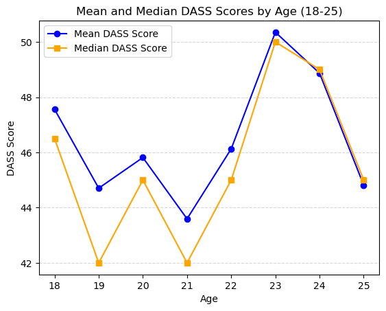

```python
# Recalculate the mean and median of DASS for the specific age range
dass_age_stats = df.groupby('Age')['DASS_total'].agg(['mean', 'median']).reset_index()

# Plot line graphs for mean and median of DASS scores by age
plt.plot(dass_age_stats['Age'], dass_age_stats['mean'], marker='o', label='Mean DASS Score', color='blue')
plt.plot(dass_age_stats['Age'], dass_age_stats['median'], marker='s', label='Median DASS Score', color='orange')
plt.title('Mean and Median DASS Scores by Age (18-25)')
plt.xlabel('Age')
plt.ylabel('DASS Score')
plt.legend()
plt.grid(axis='y', linestyle='--', alpha=0.5)
plt.show()
```

Based on this graph, we can see the trend of both mean and median repaidly waive between 18 to 21, and then repaidly grow and reach to the peak in 23 years old. That indicates that students in their early 20s may face heightened levels of depression, anxiety, and stress. After 23, the scores start to stabilize or show a slight decrease, which indicates that older students might have adapted better or developed more effective coping strategies to mental concerns.

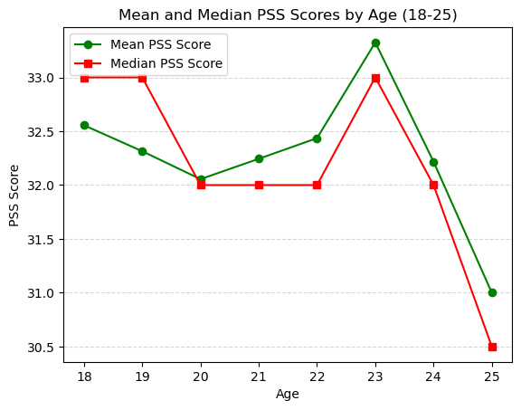

```python
# Recalculate the mean and median of PSS scores for the specific age range
pss_age_stats = df.groupby('Age')['PSS_total'].agg(['mean', 'median']).reset_index()

# Plot line graphs for mean and median of PSS scores by age
plt.plot(pss_age_stats['Age'], pss_age_stats['mean'], marker='o', label='Mean PSS Score', color='green')
plt.plot(pss_age_stats['Age'], pss_age_stats['median'], marker='s', label='Median PSS Score', color='red')
plt.title('Mean and Median PSS Scores by Age (18-25)')
plt.xlabel('Age')
plt.ylabel('PSS Score')
plt.legend()
plt.grid(axis='y', linestyle='--', alpha=0.5)
plt.show()
```

Similar to the graph of the DASS, the mean and median of PSS waive between 18 to 21, and start to grow at 21, and reach to the peak at 23 years old. After that, the trends starts to have a significant decrease. That may indicate older students might have learned to manage stress better or have different stressors compared to younger peers.

## 2. The Distribution of DASS And PSS Score Based on Gender

This section aims to compare the distribution of DASS and PSS scores across gender groups (including males, females, non-binary/Genderqueer, and other/not listed). The purpose of this visualization is to explore whether there are significant gender differences in mental health outcomes among 18-25 year old students. By analyzing median scores and variability, we hope to uncover potential differences. This is important because gender-specific mental health challenges may indicate the need to develop inclusive and effective interventions and support systems for all gender identities.

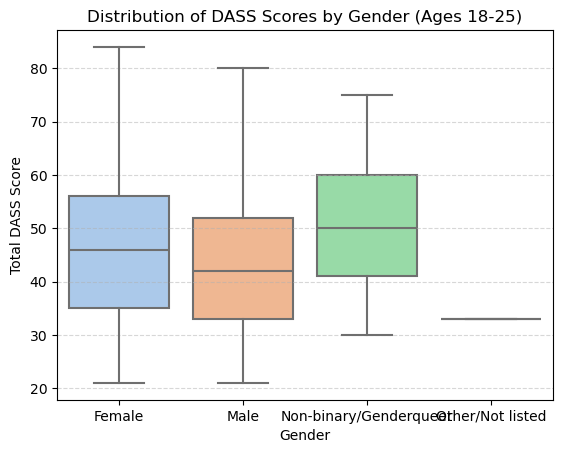

```python
# Create box plots for DASS scores by Gender
sns.boxplot(data=df, x='Gender', y='DASS_total', palette='pastel', showfliers=False)
plt.title('Distribution of DASS Scores by Gender (Ages 18-25)')
plt.xlabel('Gender')
plt.ylabel('Total DASS Score')
plt.grid(axis='y', linestyle='--', alpha=0.5)
plt.show()
```

This box plot for DASS scores across gender groups (Male, Female, Non-binary/Genderqueer, and Other/Not listed) shows distinct variations in mental health experiences.

Females tend to have a higher median DASS score compared to males, which suggests that on average, women may report higher levels of depression, anxiety, and stress. The interquartile range for females is also broader, that indicates the more variability in their responses than males.

Non-binary/Genderqueer participants often show a narrowed spread, with high medians lower quantile, upper quantile, and highest smallest value that suggest extreme scores. This can point to significant mental health challenges faced by individuals in this group, potentially due to unique societal pressures or lack of adequate support systems.

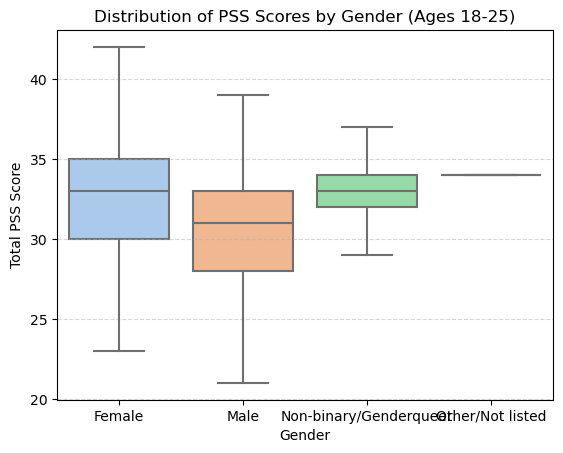

```python
# Create box plots for PSS scores by Gender
sns.boxplot(data=df, x='Gender', y='PSS_total', palette='pastel', showfliers=False)
plt.title('Distribution of PSS Scores by Gender (Ages 18-25)')
plt.xlabel('Gender')
plt.ylabel('Total PSS Score')
plt.grid(axis='y', linestyle='--', alpha=0.5)
plt.show()
```

In this PSS score distribution, females again show a higher median compared to males, which indicates that females perceive their environment as more stressful on average. This trend aligns with common findings in mental health research where females often report higher stress due to a combination of academic, social, and personal factors.

## 3. DASS and PSS Among Different Ethinical Groups

This analysis focuses on differences in median DASS and PSS scores across ethnic groups (including Caucasian, Asian, Native, Hispanic/Latino, Black, etc.). The goal is to determine which ethnic groups report higher or lower levels of depression, anxiety, stress, and perceived stress. This insight helps identify specific populations that may need additional mental health resources. Understanding mental health trends related to ethnicity is critical because it highlights unique stressors or cultural factors that affect certain groups, allowing for the development of culturally sensitive supports.

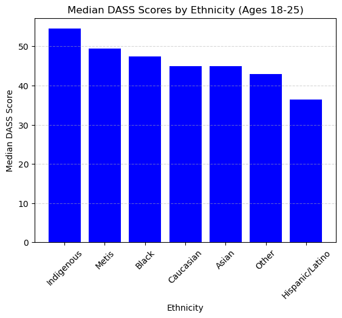

```python
# Calculate mean and median for DASS and PSS scores by Ethnicity
dass_ethnicity_stats = df.groupby('Ethnicity')['DASS_total'].agg(['mean', 'median']).sort_values(by='median', ascending=False).reset_index()
pss_ethnicity_stats = df.groupby('Ethnicity')['PSS_total'].agg(['mean', 'median']).sort_values(by='median', ascending=False).reset_index()

# Plot bar graphs for median of DASS scores by Ethnicity (descending order)
plt.bar(dass_ethnicity_stats['Ethnicity'], dass_ethnicity_stats['median'], color='blue')
plt.title('Median DASS Scores by Ethnicity (Ages 18-25)')
plt.xlabel('Ethnicity')
plt.ylabel('Median DASS Score')
plt.xticks(rotation=45)
plt.grid(axis='y', linestyle='--', alpha=0.5)
plt.show()
```

The bar graph indicates that Indigenous, Metis, and Black students report the highest median DASS scores among the age group 18-25. This suggests that these groups may face higher levels of depression, anxiety, and stress compared to other ethnicities. These results could be influenced by unique challenges such as systemic inequalities, cultural stigma around mental health, or limited access to mental health resources.

Hispanic/Latino students show relatively lower median DASS scores, suggesting that they may experience less challenges related to stress and anxiety.

Caucasian and Asian students display lower median DASS scores than Indigenous, Metis, and Black students, but higher than Hispanic/Latino students, which indicates on average, these groups report less severe levels of depression, anxiety, and stress. While these groups still face mental health challenges, their experiences may differ in intensity compared to other ethnic groups.

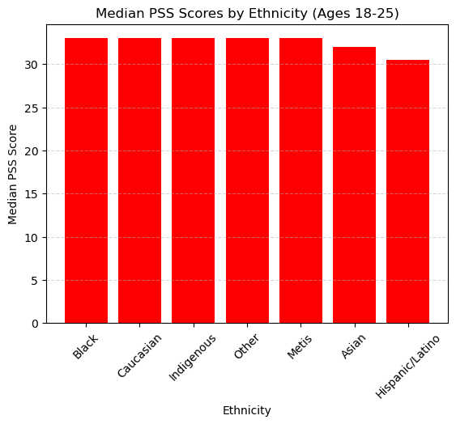

```python
# Plot bar graphs for median of PSS scores by Ethnicity (descending order)
plt.bar(pss_ethnicity_stats['Ethnicity'], pss_ethnicity_stats['median'], color='red')
plt.title('Median PSS Scores by Ethnicity (Ages 18-25)')
plt.xlabel('Ethnicity')
plt.ylabel('Median PSS Score')
plt.xticks(rotation=45)
plt.grid(axis='y', linestyle='--', alpha=0.5)
plt.show()
```

The bar graph for median PSS scores shows that Hispanic/Latino and Asian students report the lowest levels of perceived stress. And all other ethical group has the same median in PSS.

## 4. DASS and PSS Across Different Academic Year

This section examines the median DASS and PSS scores of students at different academic levels, from freshmen (1st grade) to super seniors (5th grade). By comparing scores across academic years, we aim to identify which stages of academic progress are associated with higher or lower mental health scores. This information is important for universities as it can inform policies and strategies to better support students as they transition into different stages of their education, where pressures and expectations may differ.

```python
# Calculate median for DASS and PSS scores by academic year
dass_year_stats = df.groupby('Year_credits')['DASS_total'].median().sort_values(ascending=False).reset_index()
pss_year_stats = df.groupby('Year_credits')['PSS_total'].median().sort_values(ascending=False).reset_index()
```

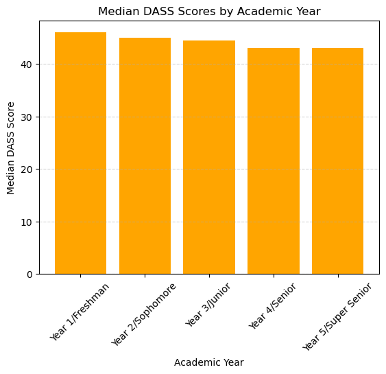

```python
# Plot bar graphs for median of DASS scores by academic year (descending order)
plt.bar(dass_year_stats['Year_credits'], dass_year_stats['DASS_total'], color='orange')
plt.title('Median DASS Scores by Academic Year')
plt.xlabel('Academic Year')
plt.ylabel('Median DASS Score')
plt.xticks(rotation=45)
plt.grid(axis='y', linestyle='--', alpha=0.5)
plt.show()
```

The bar graph of median DASS scores by academic years shows that Year 4/Senior and Year 5/Super Senior students have the lower median DASS scores than others, which indicates that these students report lower levels of depression, anxiety, and stress compared to those in earlier years. This probably is bacause they have adapted or found the ways to dead with the mental concerns after the first several years of studying, which is proofed by the median of Year 1, Year 2 and Year 3 students, which have the highest median scores of DASS, but graduately descrease as time goes one.

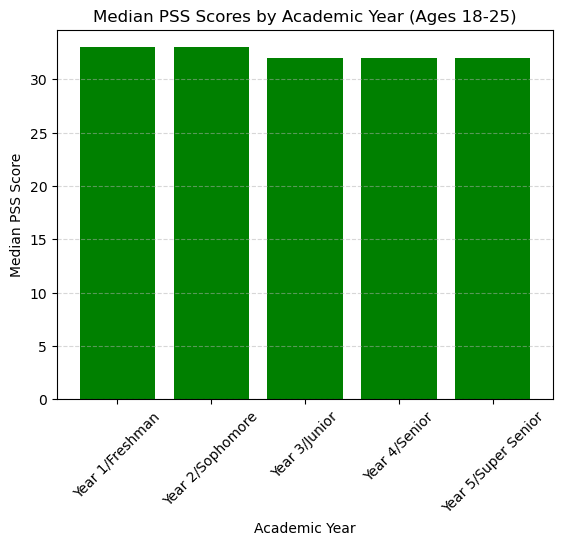

```python
plt.bar(pss_year_stats['Year_credits'], pss_year_stats['PSS_total'], color='green')
plt.title('Median PSS Scores by Academic Year (Ages 18-25)')
plt.xlabel('Academic Year')
plt.ylabel('Median PSS Score')
plt.xticks(rotation=45)
plt.grid(axis='y', linestyle='--', alpha=0.5)
plt.show()
```

Similar to the median DASS scores by academic years, the bar graph for PSS scores also ranks Year 1/Freshman students and Year 2/Sophomore students with the highest median perceived stress scores. From year 3, the perceived stress scores don't change significantly. This further proved that students in younger grades may have more mental health challenges than the ones in older grades, as they may need more time to adapt to college/university study.

## 5. DASS and PSS Differed by Living Arrangements

This section explores how living arrangements (e.g., on-campus housing, living alone off-campus, living with family or friends) affect the median score of DASS and the median PSS scores. The goal is to understand whether different residential settings lead to different levels of mental health problems among students. The insights gained from this analysis are important because they can inform housing policies and support services, emphasizing the need for community-building initiatives or additional support for students who may be more vulnerable, such as those living alone.

```python
# Calculate median for DASS and PSS scores by living situation
dass_living_stats = df.groupby('Living')['DASS_total'].median().sort_values(ascending=False).reset_index()
pss_living_stats = df.groupby('Living')['PSS_total'].median().sort_values(ascending=False).reset_index()
```

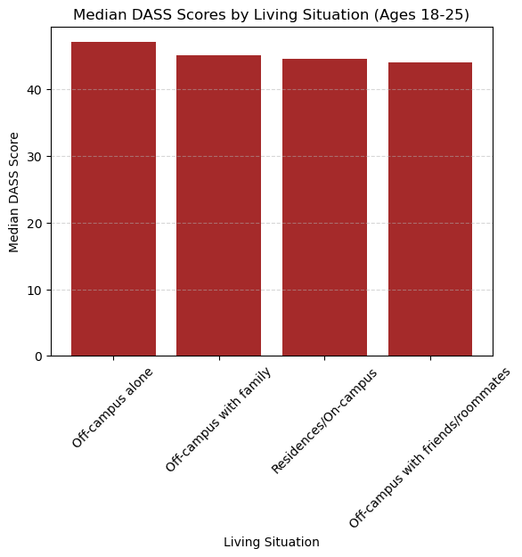

```python
# Plot bar graphs for median DASS scores by living situation (descending order)
plt.bar(dass_living_stats['Living'], dass_living_stats['DASS_total'], color='brown')
plt.title('Median DASS Scores by Living Situation (Ages 18-25)')
plt.xlabel('Living Situation')
plt.ylabel('Median DASS Score')
plt.xticks(rotation=45)
plt.grid(axis='y', linestyle='--', alpha=0.5)
plt.show()
```

The bar graph indicates that students living off-campus alone report the highest median DASS scores. This suggests that living alone may be associated with higher levels of depression, anxiety, and stress, possibly due to feelings of isolation or the challenges of managing responsibilities independently.

Students living off-campus with friends/roommates show the lowest median scores, which could reflect the positive impact of social support from peers. It is even lower than students living off-campus with family.

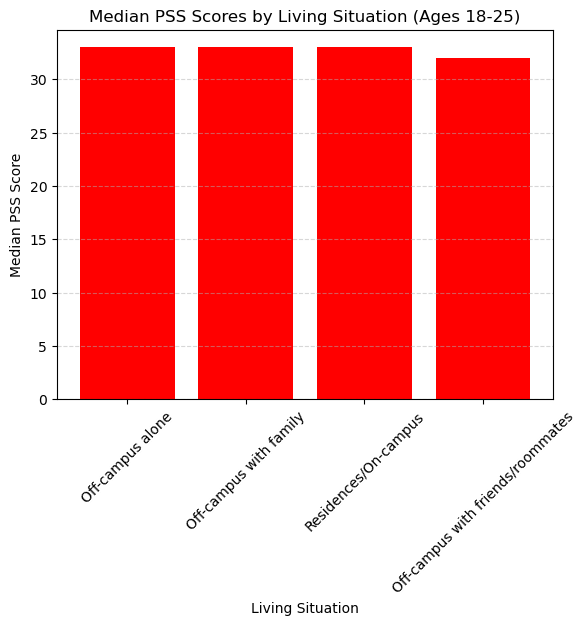

```python
# Plot bar graphs for median PSS scores by living situation (descending order)
plt.bar(pss_living_stats['Living'], pss_living_stats['PSS_total'], color='red')
plt.title('Median PSS Scores by Living Situation (Ages 18-25)')
plt.xlabel('Living Situation')
plt.ylabel('Median PSS Score')
plt.xticks(rotation=45)
plt.grid(axis='y', linestyle='--', alpha=0.5)
plt.show()
```

The PSS scores on the groups of students whose living off-campus alone, living off-campus with family, living on-campus are basically in the same level. However, the the PSS score on the student group who live off-campus with friends/roommates is slightly lower than those 3 groups.

## 6. DASS and PSS Scores of Different Exercise Type Changes Based on Exercise Frequency

This visualization analyzes the relationship between students' frequency of exercise (vigorous, moderate, and light) and median DASS and PSS scores. The goal is to look at patterns and determine whether certain types or frequencies of physical activity are associated with better or worse mental health outcomes. This analysis will highlight the role of physical activity in mental health and helps promote the use of exercise as part of student wellness programs.

```python
# Create bar graphs for median DASS and PSS scores by exercise frequency (strenuous, moderate, mild)
exercise_columns = ['Strenous exercise', 'Moderate exercise', 'Mild exercise']
# Calculate median DASS and PSS scores by exercise type
dass_exercise_stats = {col: df.groupby(col)['DASS_total'].median().sort_index() for col in exercise_columns}
pss_exercise_stats = {col: df.groupby(col)['PSS_total'].median().sort_index() for col in exercise_columns}
```

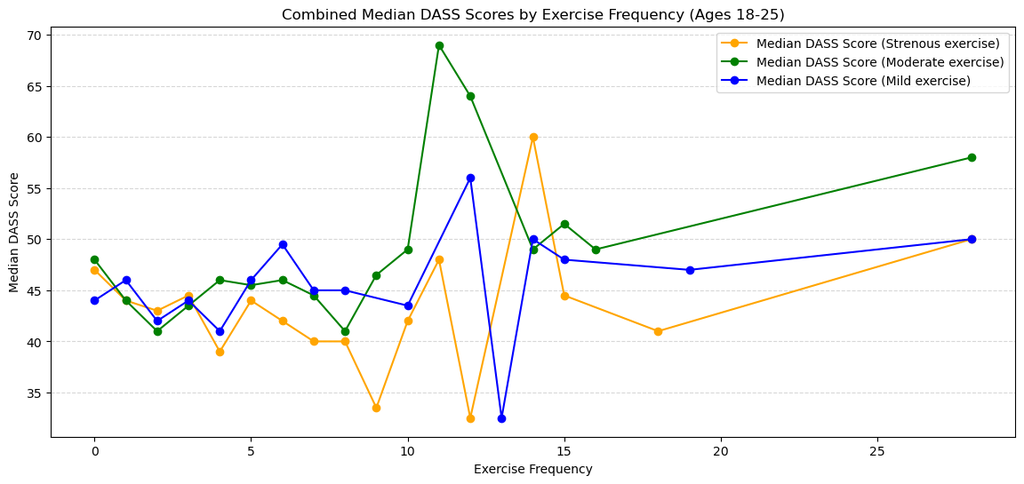

```python
colors = ['orange', 'green', 'blue']
exercise_types = ['Strenous exercise', 'Moderate exercise', 'Mild exercise']
plt.figure(figsize=(14, 6))

for col, color in zip(exercise_columns, colors):
    plt.plot(dass_exercise_stats[col].index, dass_exercise_stats[col].values,
             marker='o', linestyle='-', color=color, label=f'Median DASS Score ({col})')

plt.title('Combined Median DASS Scores by Exercise Frequency (Ages 18-25)')
plt.xlabel('Exercise Frequency')
plt.ylabel('Median DASS Score')
plt.grid(axis='y', linestyle='--', alpha=0.5)
plt.legend()
plt.show()
```

Based on the plot of 'Combined Median DASS Scores by Exercise Frequency (Ages 18-25):

**Strenuous Exercise (orange line)**: DASS scores for strenuous exercise show differences across frequencies, with distinct peaks and troughs. This suggests that while moderate-intensity vigorous exercise may be beneficial to mental health, very high or erratic frequencies may increase stress and anxiety.

**Moderate exercise (green line)**: the median DASS score for moderate-intensity exercise shows significant peaks, suggesting that moderate-intensity exercise may be associated with increased emotional distress at a given frequency. The graph suggests that moderate-intensity exercise may be both beneficial and potentially stressful, depending on the duration of the exercise.

**Mild Exercise (blue line)**: the light exercise line looks more stable, but still shows some fluctuations. This suggests that while light exercise may contribute to overall health, it may not have a significant impact on levels of major depression, anxiety, or stress unless combined with a more regular routine.

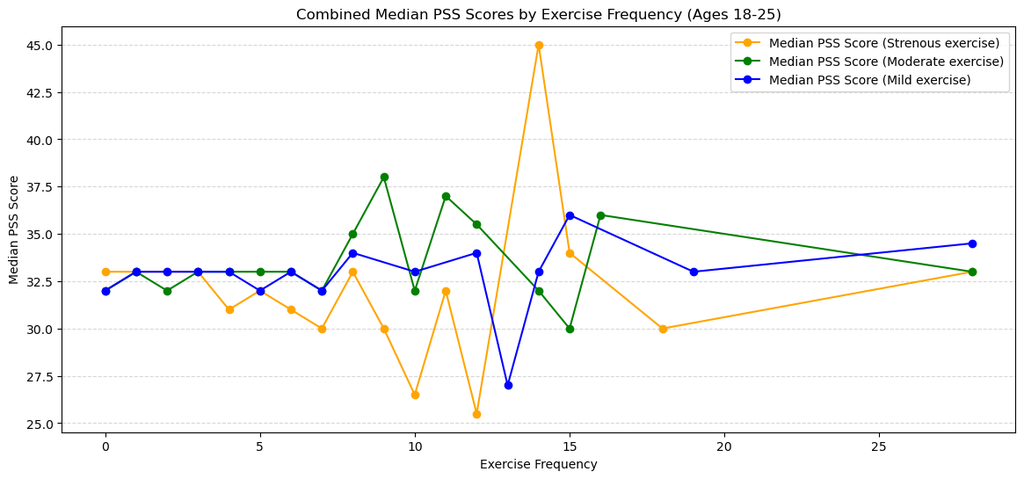

```python
# Plot combined line graph for median PSS scores by exercise frequency
plt.figure(figsize=(14, 6))

for col, color in zip(exercise_columns, colors):
    plt.plot(pss_exercise_stats[col].index, pss_exercise_stats[col].values,
             marker='o', linestyle='-', color=color, label=f'Median PSS Score ({col})')

plt.title('Combined Median PSS Scores by Exercise Frequency (Ages 18-25)')
plt.xlabel('Exercise Frequency')
plt.ylabel('Median PSS Score')
plt.grid(axis='y', linestyle='--', alpha=0.5)
plt.legend()
plt.show()
```

Combined Median PSS Scores by Exercise Frequency:

**Strenuous Exercise (orange line):** PSS scores for strenuous exercise show a similar pattern to DASS scores, with fluctuations indicating inconsistency or high frequency that may correspond to increased perceived stress. Consistent, moderate frequencies may help control stress levels.

**Moderate Exercise (Green Line):** The median PSS score shows a distinct peak for moderate intensity exercise, meaning that at some point, perceived stress may be higher, which may be due to overexertion or an irregular pattern. A consistent, well-managed exercise program appears to alleviate stress.

**Mild Exercise (blue line):** PSS scores for mild exercise remain relatively stable, reflecting the fact that mild exercise may help to reduce perceived stress, but may not significantly reduce perceived stress compared to more strenuous activities.

## 7. DASS and PSS Score of Different Sleep Status Changes Based on Sleep Hours

This section will examine how the number of hours of sleep and subjective perceptions of being well-rested (yes, somewhat, no) affect the DASS and median PSS scores, to understand the relationship between sleep quality and duration and student mental health indicators. This analysis will highlight the role of sleep in managing stress, anxiety, and depression and emphasize the importance of sleep education as part of student wellness programs.

```python
# Group data by 'Hours_sleep' and 'Rested' to calculate median DASS and PSS scores
dass_combined_stats = df.groupby(['Hours_sleep', 'Rested'])['DASS_total'].median().unstack()
pss_combined_stats = df.groupby(['Hours_sleep', 'Rested'])['PSS_total'].median().unstack()
```

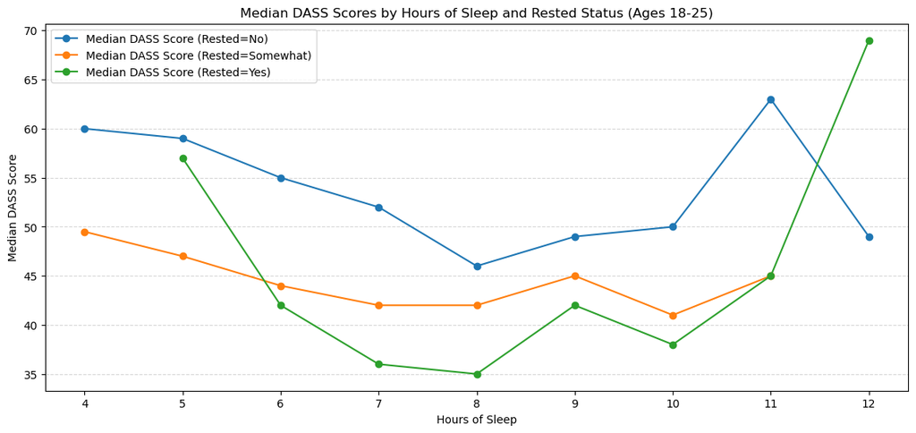

```python
# Plot combined line graph for median DASS scores by hours of sleep and rested status
plt.figure(figsize=(14, 6))
for status in dass_combined_stats.columns:
    plt.plot(dass_combined_stats.index, dass_combined_stats[status], marker='o', linestyle='-', label=f'Median DASS Score (Rested={status})')

plt.title('Median DASS Scores by Hours of Sleep and Rested Status (Ages 18-25)')
plt.xlabel('Hours of Sleep')
plt.ylabel('Median DASS Score')
plt.grid(axis='y', linestyle='--', alpha=0.5)
plt.legend()
plt.show()
```

Based on the Median DASS Scores by Hours of Sleep and Rested Status:

The overall trends of all those 3 lines tend to decrease as hours of sleep increase until the hours of sleep reaches to 8 hours, where the trend starts to increase.

**Rested = Somewhat (Orange Line):** This group shows moderately high DASS scores that decrease with more sleep (before reaches to 8 hours) but are consistently lower than the "Rested = No" group. The decreasing trend remain relatively more stable before 8 hours, compared to other groups.

**Rested = Yes (Green Line):** Participants who feel well-rested have the lowest DASS scores in overall. Their scores show a clear decline as sleep hours increase up to around 8 hours, which indicates that being well-rested and having adequate sleep is strongly linked to better mental health. However, the increase of DASS score after 8 hours sleep is more intensive than other 2 groups.

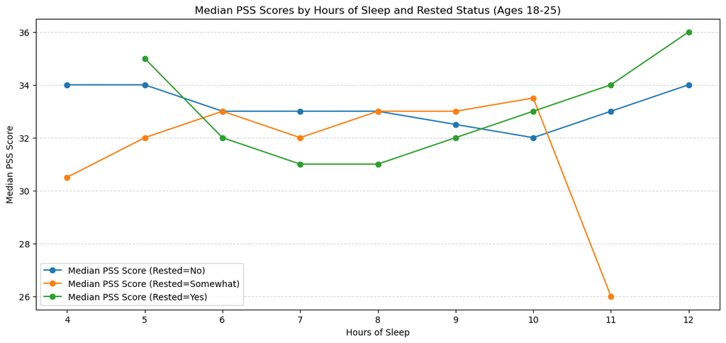

```python
# Plot combined line graph for median PSS scores by hours of sleep and rested status
plt.figure(figsize=(14, 6))
for status in pss_combined_stats.columns:
    plt.plot(pss_combined_stats.index, pss_combined_stats[status], marker='o', linestyle='-', label=f'Median PSS Score (Rested={status})')

plt.title('Median PSS Scores by Hours of Sleep and Rested Status (Ages 18-25)')
plt.xlabel('Hours of Sleep')
plt.ylabel('Median PSS Score')
plt.grid(axis='y', linestyle='--', alpha=0.5)
plt.legend()
plt.show()
```

## 8. DASS and PSS Scores Based on Social Support and Mindfulness:

This section explores the relationship between total scores on Seeking Social Support (SSS) and Cognitive Affective Positive Thinking (CAMS) and median DASS and PSS scores. By analyzing these relationships, we aimed to determine the impact of social support and positive thinking practice on mental health outcomes, and provide the guidence of the development of mental health programs and workshops aimed at building resilience and stress management in students.

```python
# Calculate total scores for SSS (Social Support) and CAMS-R (Mindfulness)
df['SSS_total'] = df[[f'SSS_{i}' for i in range(1, 13)]].sum(axis=1)
df['CAMS_R_total'] = df[[f'CAMS_{i}' for i in range(1, 13)]].sum(axis=1)

# Group data by SSS and CAMS-R total scores to calculate median DASS and PSS scores
dass_support_stats = df.groupby('SSS_total')['DASS_total'].median().sort_index()
pss_support_stats = df.groupby('SSS_total')['PSS_total'].median().sort_index()
dass_mindfulness_stats = df.groupby('CAMS_R_total')['DASS_total'].median().sort_index()
pss_mindfulness_stats = df.groupby('CAMS_R_total')['PSS_total'].median().sort_index()
```

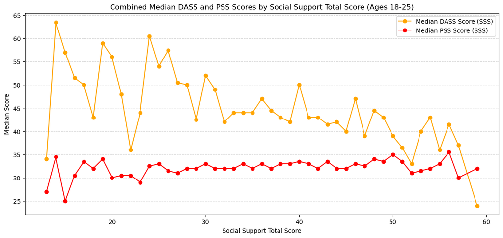

```python
# Plot combined line graph for median DASS and PSS scores by SSS total score
plt.figure(figsize=(14, 6))
plt.plot(dass_support_stats.index, dass_support_stats.values, marker='o', linestyle='-', color='orange', label='Median DASS Score (SSS)')
plt.plot(pss_support_stats.index, pss_support_stats.values, marker='o', linestyle='-', color='red', label='Median PSS Score (SSS)')
plt.title('Combined Median DASS and PSS Scores by Social Support Total Score (Ages 18-25)')
plt.xlabel('Social Support Total Score')
plt.ylabel('Median Score')
plt.grid(axis='y', linestyle='--', alpha=0.5)
plt.legend()
plt.show()
```

Based on Combined Median DASS and PSS Scores by Social Support Total Score:

**DASS (Orange Line):** The median DASS scores show considerable fluctuations as social support total scores increase. Initially, there is a high score that decreases as social support scores improve, that indicate that the higher levels of social support may be linked to reduced levels of depression, anxiety, and stress. However, the presence of peaks suggests that not all levels of social support provide consistent emotional benefits.

**PSS (Red Line):** The median PSS scores are more stable compared to DASS. The trend is less pronounced, which means we cannot easily tell if the perceived stress may improve with social support.

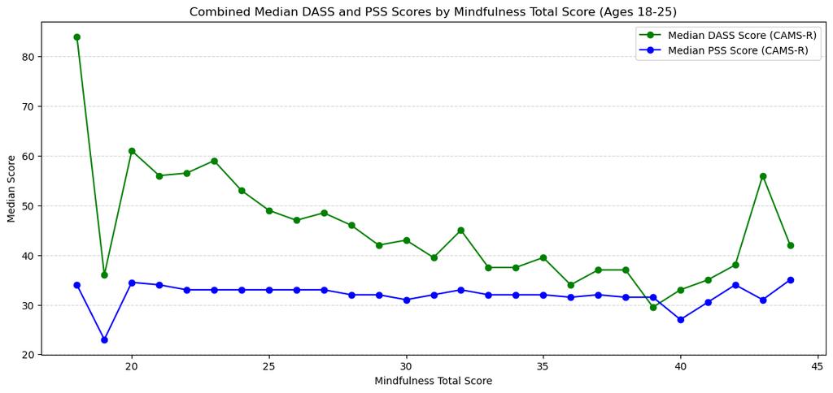

```python
# Plot combined line graph for median DASS and PSS scores by CAMS-R total score
plt.figure(figsize=(14, 6))
plt.plot(dass_mindfulness_stats.index, dass_mindfulness_stats.values, marker='o', linestyle='-', color='green', label='Median DASS Score (CAMS-R)')
plt.plot(pss_mindfulness_stats.index, pss_mindfulness_stats.values, marker='o', linestyle='-', color='blue', label='Median PSS Score (CAMS-R)')
plt.title('Combined Median DASS and PSS Scores by Mindfulness Total Score (Ages 18-25)')
plt.xlabel('Mindfulness Total Score')
plt.ylabel('Median Score')
plt.grid(axis='y', linestyle='--', alpha=0.5)
plt.legend()
plt.show()
```

Based on Combined Median DASS and PSS Scores by Mindfulness Total Score:

**PSS (Blue Line):** The PSS scores remain relatively stable and lower compared to DASS scores. There is a slight downward trend, implying that mindfulness helps in reducing perceived stress, but the effect is less marked than for DASS.

Overall, the social support is linked to decreased DASS and PSS scores, but the relationship with perceived stress (PSS) is less significant compared to DASS. This suggests that while seeking social support helps in managing stress and emotional challenges, its effectiveness varies. Additionally, mindfulness practices show a clear and consistent association with lower DASS scores, which highlights its potential as an effective coping mechanism for improving mental health. The effect on perceived stress (PSS) is present but more gradual.